# Анализ вакансий аналитиков на hh.ru

### Парсинг данных hh.ru

Всю информацию о получении данных по API можно найти в [документации](https://github.com/hhru/api). Зададим функции используя доступ по API и библиотеку [BeautifulSoup](https://pypi.org/project/beautifulsoup4/#description) для текста описания вакансий.

```python
# Зададим функции для парсинга данных
'''
В ДАННОЙ ЯЧЕЙКЕ ИСПОЛЬЗУЕМ «ДЕМО-ВЕРСИЮ» ПОЛУЧИВШЕЙСЯ ФУНКЦИИ ДЛЯ СБОРКИ ДАТАСЕТА,
АТРИБУТЫ ФУНКЦИИ ИЗМЕНЕНЫ С ЦЕЛЬЮ УМЕНЬШЕНИЯ ЗАДЕРЖКИ ВЫВОДА
ФУНКЦИЯ ВЫВОДИТ ПЕРВУЮ СТРАНИЦУ ДАННЫХ ПО ВАКАНСИЯМ ЗА ВЧЕРАШНЮЮ ДАТУ
'''
BASE_URL = "https://api.hh.ru/vacancies"
HEADERS = {"HH-User-Agent": "my_"}


# Зададим функцию для определения диапазоны дат за которые мы хотим получить данные
def get_vacancies_by_date_range(position, date_from, date_to, max_pages=1):
    """
    Получение вакансий за указанный диапазон дат.
    """
    vacancies = []
    for page in range(max_pages):
        params = {
            "text": position,
            "page": page,
            "per_page": 20,  # Максимальное количество вакансий на странице
            "date_from": date_from,
            "date_to": date_to,
        }

        response = requests.get(BASE_URL, headers=HEADERS, params=params)

        if response.status_code != 200:
            print(f"Ошибка запроса на странице {page} с кодом {response.status_code}")
            break

        data = response.json()
        vacancies.extend(data["items"])  # Добавляем вакансии из текущей страницы

        # Если достигнут конец доступных страниц, выходим из цикла
        if page >= data.get("pages", 1) - 1:
            break

        # Пауза, чтобы избежать ограничения по количеству запросов к API HH.ru
        time.sleep(1)

    return vacancies
#
def get_vacancies_data(position, start_date="2024-11-15", end_date="2024-11-24"):
    """
    Основная функция для получения вакансий с разбивкой по диапазонам дат.
    """
    step = timedelta(weeks=1)
    current_date = datetime.strptime(start_date, "%Y-%m-%d")
    end_date = datetime.strptime(end_date, "%Y-%m-%d")

    all_vacancies = []

    while current_date < end_date:
        next_date = min(current_date + step, end_date)
        date_from = current_date.strftime("%Y-%m-%d")
        date_to = next_date.strftime("%Y-%m-%d")

        vacancies = get_vacancies_by_date_range(position, date_from, date_to)
        all_vacancies.extend(vacancies)

        current_date = next_date

    # Преобразуем в формат, соответствующий вашей структуре
    relevant_keywords = [
        "аналитик данных", "data analyst", "системный аналитик",
        "system analyst", "bi-analyst", "дата аналитик", "бизнес/системный аналитик"
    ]

    parsed_vacancies = []
    # Прогресс-бар для обработки вакансий
    with tqdm(total=len(all_vacancies), desc="Обработка вакансий") as pbar:
        for item in all_vacancies:
            # Фильтрация по ключевым словам в названии вакансии
            if not any(keyword.lower() in item["name"].lower() for keyword in relevant_keywords):
                continue

            salary = item.get("salary")
            vacancy_data = {
                "id": item.get("id"),
                "name": item.get("name"),
                "published_at": item.get("published_at"),
                "alternate_url": item.get("alternate_url"),
                "type": item.get("type"),
                "employer": item.get("employer", {}).get("name"),
                "department": item.get("department", {}).get("name") if item.get("department") else None,
                "area": item.get("area", {}).get("name"),
                "experience": item.get("experience", {}).get("name"),
                "schedule": item.get("schedule", {}).get("name"),
                "employment": item.get("employment", {}).get("name"),
                "salary_from": salary["from"] if salary else None,
                "salary_to": salary["to"] if salary else None,
            }
            parsed_vacancies.append(vacancy_data)
            pbar.update(1)

    return pd.DataFrame(parsed_vacancies)

def enrich_vacancies_data(df):
    """
    Дополняем вакансии описанием и ключевыми навыками.
    """
    def description(vacancy_id):
        url = f'https://api.hh.ru/vacancies/{vacancy_id}'
        response = requests.get(url, headers=HEADERS)
        if response.status_code == 200:
            description_html = response.json().get('description', '')
            return BeautifulSoup(description_html, "html.parser").get_text().lower()
        else:
            print(f"Ошибка при получении описания для вакансии ID: {vacancy_id}")
            return None

    tqdm.pandas(desc="Загрузка описаний вакансий")
    df["description"] = df["id"].progress_apply(description)

    def get_vacancy_skills(vacancy_id):
        url = f'https://api.hh.ru/vacancies/{vacancy_id}'
        response = requests.get(url, headers=HEADERS)
        if response.status_code == 200:
            data = response.json()
            skills = [skill['name'] for skill in data.get('key_skills', [])]
            return ', '.join(skills) if skills else None
        return None

    tqdm.pandas(desc="Загрузка ключевых навыков")
    df["key_skills"] = df["id"].progress_apply(get_vacancy_skills)

    return df

# Сбор данных
# Зададим значение текущей даты для демо-режима функции
today = datetime.today().strftime('%Y-%m-%d')
yesterday = (datetime.today() - timedelta(days=1)).strftime('%Y-%m-%d')

df_analyst = get_vacancies_data(position="Аналитик данных", start_date=yesterday, end_date=today)
df_system_analyst = get_vacancies_data(position="Системный аналитик", start_date=yesterday, end_date=today)

# Объединение результатов
df = pd.concat([df_analyst, df_system_analyst], ignore_index=True)

# Обогащение данных
df = enrich_vacancies_data(df)

# Вывод и сохранение результатов
print(f"Общее количество вакансий на первой странице за {yesterday}: {len(df)}")
df.head()
```

```
Общее количество вакансий на первой странице за 2024-11-22: 9
```

|  | id | name | published_at | alternate_url | type | employer | department | area | experience | schedule | employment | salary_from | salary_to | description | key_skills |
| --- | --- | --- | --- | --- | --- | --- | --- | --- | --- | --- | --- | --- | --- | --- | --- |
| 0 | 111556122 | Аналитик данных | 2024-11-23T13:45:37+0300 | https://hh.ru/vacancy/111556122 | {'id': 'open', 'name': 'Открытая'} | SMART TECHNOLOGY SYSTEMS | None | Ташкент | Нет опыта | Полный день | Полная занятость | 4000000.00 | None | обязанности:- сбор данных о продажах, клиентах... | MS Excel, Исследовательский анализ данных, Раб... |
| 1 | 111417913 | Стажер/ Младший системный аналитик | 2024-11-23T13:11:25+0300 | https://hh.ru/vacancy/111417913 | {'id': 'open', 'name': 'Открытая'} | Солантек | None | Санкт-Петербург | Нет опыта | Гибкий график | Стажировка | NaN | NaN | solanteq - команда экспертов в области платежн... | SQL, Linux, PostgreSQL, Git, Java, Английский ... |
| 2 | 111586797 | Помощник системного аналитика/младший системны... | 2024-11-22T13:10:34+0300 | https://hh.ru/vacancy/111586797 | {'id': 'open', 'name': 'Открытая'} | МОССклад | None | Москва | Нет опыта | Полный день | Полная занятость | 92000.00 | 120000.00 | о компании: история компании начинается с 2006... | None |
| 3 | 111441716 | Системный аналитик | 2024-11-23T17:22:42+0300 | https://hh.ru/vacancy/111441716 | {'id': 'open', 'name': 'Открытая'} | Система Продаж | None | Москва | От 1 года до 3 лет | Удаленная работа | Полная занятость | 100000.00 | 130000.00 | давайте знакомиться, мы компания stocrm - росс... | None |
| 4 | 110113123 | Системный аналитик (удаленно) | 2024-11-23T11:27:31+0300 | https://hh.ru/vacancy/110113123 | {'id': 'open', 'name': 'Открытая'} | ИТЛаб | None | Москва | От 1 года до 3 лет | Полный день | Полная занятость | 100000.00 | 140000.00 | требуемые знания и навыки мы рассчитываем, что... | use cases, сценарии использования, Спецификаци... |

Мы получили первичные данные с hh.ru, теперь их следует предобработать и дополнить.

#### Выполним лемматизацию текста в поле `description`

С целью упрощения анализа воспользуемся библиотекой pymorphy2 для лемматизации и нормализации текста в поле `description` и создадим поле `description_lemmatized`

```python
# Инициализация морфологического анализатора
morph = pymorphy2.MorphAnalyzer()

# Функция для лемматизации текста с удалением знаков препинания, но с сохранением дефиса и "/"
def lemmatize_text(text):
    if not isinstance(text, str):  # Проверка, что текст является строкой
        return ''  # Возвращаем пустую строку для не строковых значений
    # Удаляем все знаки препинания, кроме дефиса и "/"
    text = re.sub(r'[^\w\s\-\/]', '', text)  # Экранируем дефис и косую черту
    # Разделяем текст на слова
    words = text.split()
    # Лемматизируем каждое слово
    lemmatized_words = [morph.parse(word)[0].normal_form for word in words]
    # Собираем слова обратно в строку
    return ' '.join(lemmatized_words)

# Применяем лемматизацию с прогресс-баром
tqdm.pandas(desc="Лемматизация текста")
df['description_lemmatized'] = df['description'].progress_apply(lemmatize_text)

# Печать результата для проверки
df[['description', 'description_lemmatized']].head(5)
```

|  | description | description_lemmatized |
| --- | --- | --- |
| 0 | обязанности:- сбор данных о продажах, клиентах... | обязанности- сбор данные о продажа клиент и ры... |
| 1 | solanteq - команда экспертов в области платежн... | solanteq - команда эксперт в область платёжный... |
| 2 | о компании: история компании начинается с 2006... | о компания история компания начинаться с 2006 ... |
| 3 | давайте знакомиться, мы компания stocrm - росс... | давать знакомиться мы компания stocrm - россий... |
| 4 | требуемые знания и навыки мы рассчитываем, что... | требовать знание и навык мы рассчитывать что в... |

Мы привели текст в поле описания вакансий к его лемматизированному что позволило:

1. Улучшить качество поиска и анализа текста
2. Повысить точность классификации текста
3. Улучшить работы методов, основанных на частотах слов (поиск уникальных навыков в описаниях вакансий) При подсчёте частоты слов в текстах (например, в анализе TF-IDF) разные формы одного и того же слова будут рассматриваться как одно слово, что делает результаты более интерпретируемыми. *Операция произведена на демо-версии датафрейма с целью снижения ожидания. Загрузим заранее обработанный датасет и продолжим работу.*

#### Переведём значения опыта в грейды.

```python
# Зададим функцию для изменения значений
def map_experience(experience):
    """
    Преобразует значения опыта работы в заданные категории.
    """
    if experience == 'От 1 года до 3 лет':
        return 'Junior+ (1-3 years)'
    elif experience == 'Нет опыта':
        return 'Junior (no expereince)'
    elif experience == 'От 3 до 6 лет':
        return 'Middle (3-6 years)'
    elif experience == 'Более 6 лет':
        return 'Senior (6+ years)'
    else:
        return 'Неизвестно'  # На случай, если появятся новые значения

# Применяем функцию к столбцу experience
df['experience'] = df['experience'].apply(map_experience)
df['experience'].value_counts()
```

```
Junior (no expereince)    5
Junior+ (1-3 years)       4
Name: experience, dtype: int64
```

## Обзор данных

```python
# Загрузим заранее подготовленный и лемматизированный датасет
df = pd.read_csv('da_sa_vacancy.csv')
```

```python
# Обзор данных
df.info()
```

```
<class 'pandas.core.frame.DataFrame'>
RangeIndex: 8143 entries, 0 to 8142
Data columns (total 16 columns):
 #   Column                  Non-Null Count  Dtype
---  ------                  --------------  -----
 0   id                      8143 non-null   int64
 1   name                    8143 non-null   object
 2   published_at            8143 non-null   object
 3   alternate_url           8143 non-null   object
 4   type                    8143 non-null   object
 5   employer                8143 non-null   object
 6   department              1837 non-null   object
 7   area                    8143 non-null   object
 8   experience              8143 non-null   object
 9   schedule                8143 non-null   object
 10  employment              8143 non-null   object
 11  salary_from             1451 non-null   float64
 12  salary_to               1070 non-null   float64
 13  description             8143 non-null   object
 14  key_skills              5724 non-null   object
 15  description_lemmatized  8143 non-null   object
dtypes: float64(2), int64(1), object(13)
memory usage: 1018.0+ KB
```

### Пропуски

```python
# Посмотрим на пропущенные значения
df.isna().mean().sort_values(ascending=False)
```

```
salary_to                0.87
salary_from              0.82
department               0.77
key_skills               0.30
id                       0.00
name                     0.00
published_at             0.00
alternate_url            0.00
type                     0.00
employer                 0.00
area                     0.00
experience               0.00
schedule                 0.00
employment               0.00
description              0.00
description_lemmatized   0.00
dtype: float64
```

В данных присутствует большое количество пропущенных значений:

- До 82-87 % пропусков в столбцах `salary_from` и `salary_to` вероятнее всего связано с тем что работодатель не стал указывать зарплату в описании вакансии;
- 77 % пропусков в поле `department` могут быть связаны как со способом сбора информации, так и с ёё отсутствием в описании;
- Поле `key_skills` содержит 30 % пропущенных значений, попробуем заполнить пропуски на основе информации содержащейся в поле `description`.

### Дубликаты

```python
# Проверим на наличие явных дубликатов
df.duplicated().sum()
```

```
0
```

Полные дубли в данных отсутствуют, проверим по полю `id`

```python
# Выведем дубликаты по полю id
# Выведем дубликаты по полю id
print(f"Количество дублей по 'id': {len(df[df.duplicated('id')])}")
```

```
Количество дублей по 'id': 0
```

Дубликаты в данных отсутствуют двигаемся дальше.

### Разведовательный анализ

#### Изучим количественные признаки

```python
# Посмотрим на описательные статистики для полей характеризующих зарплату
df[['salary_from', 'salary_to']].describe().T
```

|  | count | mean | std | min | 25% | 50% | 75% | max |
| --- | --- | --- | --- | --- | --- | --- | --- | --- |
| salary_from | 1451.00 | 175284.58 | 765656.97 | 50.00 | 75000.00 | 120000.00 | 200000.00 | 20000000.00 |
| salary_to | 1070.00 | 228310.40 | 920598.33 | 250.00 | 100000.00 | 180000.00 | 280000.00 | 30000000.00 |

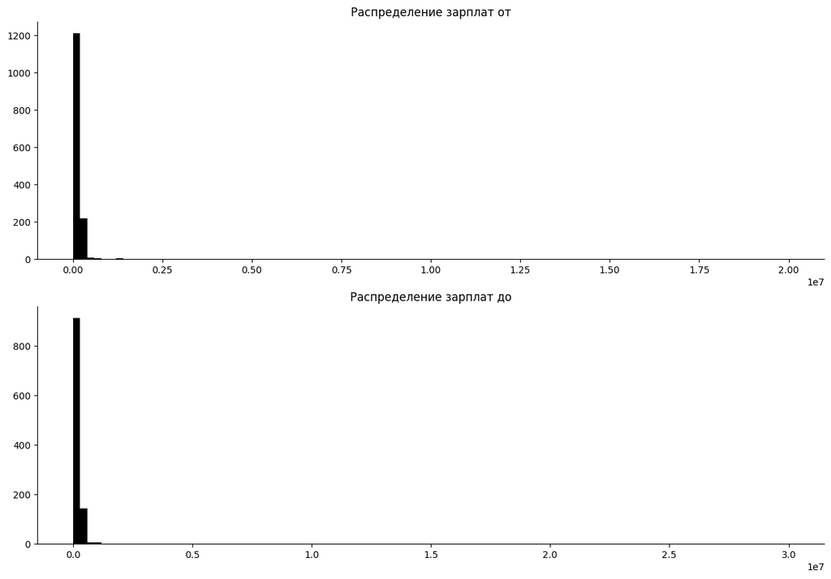

```python
# Изучим распределения
fig, axes = plt.subplots(nrows=2, ncols=1, figsize=(15, 10))
axes[0].hist(df['salary_from'], bins=100, color='black')
axes[0].set_title('Распределение зарплат от')
axes[1].hist(df['salary_to'], bins=100, color='black')
axes[1].set_title('Распределение зарплат до')
sns.despine()
# Показываем графики
plt.show()
```

Распределения имеют аномально большие значения, а также близкие к нулю, избавимся от аномальных значений на этапе предобработки.

#### Изучим категориальные признаки

```python
# Изучим названия вакансий
df.name.value_counts(normalize=True).head(15)
```

```
Системный аналитик            0.19
Аналитик данных               0.09
Системный аналитик 1С         0.02
Ведущий системный аналитик    0.02
Продуктовый аналитик          0.02
Data Analyst                  0.01
Старший системный аналитик    0.01
Системный аналитик DWH        0.01
System Analyst                0.00
Ведущий аналитик данных       0.00
BI-аналитик                   0.00
Младший аналитик данных       0.00
Системный аналитик (Middle)   0.00
System analyst                0.00
Data analyst                  0.00
Name: name, dtype: float64
```

Присутствует множество различных названий характеризующих одни и теже профессии, стоит привести к единому значению для проведения анализа.

```python
# Изучим работодателей
df.employer.value_counts(normalize=True).head()
```

```
СБЕР                    0.07
Т1                      0.03
Aston                   0.01
Ozon                    0.01
Совкомбанк Технологии   0.01
Name: employer, dtype: float64
```

Неявные дубликаты не обнаружены, будем считать что названия работодателей указаны без ошибок. Сбер лидирует среди работодателей.

```python
# Изучим значения отделов работодателей
df.department.value_counts(normalize=True).head()
```

```
Сбер для экспертов                             0.28
ГК Иннотех | разработка ИТ-решений (Иннотех)   0.05
ГК Иннотех | Финтех (Иннотех)                  0.03
Газпромбанк                                    0.03
ПАО «Промсвязьбанк», ИТ                        0.03
Name: department, dtype: float64
```

Множество различных значений, на данном этапе сложно оценить полезность данного поля для анализа.

```python
# Изучим местоположение работодателей
df.area.value_counts(normalize=True).head()
```

```
Москва            0.62
Санкт-Петербург   0.11
Екатеринбург      0.03
Казань            0.02
Новосибирск       0.02
Name: area, dtype: float64
```

```python
# Изучим требуемый опыт работы
df.experience.value_counts(normalize=True)
```

```
Неизвестно               0.39
Junior+ (1-3 years)      0.31
Middle (3-6 years)       0.26
Junior (no experience)   0.03
Senior (6+ years)        0.01
Name: experience, dtype: float64
```

Почти 40 % значений значатся как «Неизвестные», попробуем обработать такие строки на основе названий и описаний вакансий, в противном случае придется отфильтровать.

```python
# Изучим тип занятости
df.employment.value_counts(normalize=True)
```

```
Полная занятость      0.98
Стажировка            0.01
Частичная занятость   0.01
Проектная работа      0.00
Волонтерство          0.00
Name: employment, dtype: float64
```

Проблем со значениями не обнаружено, наиболее востребованными являются Junior+ специалисты.

```python
# Изучим тип занятости
df.schedule.value_counts(normalize=True)
```

```
Полный день        0.69
Удаленная работа   0.28
Гибкий график      0.03
Сменный график     0.00
Name: schedule, dtype: float64
```

Проблем со значениями не обнаружено, большинство работодателей предлагают работу в офисе.

```python
# Изучим ключевые навыки
df.key_skills.value_counts(normalize=True).head(10)
```

```
[]                                               0.09
['Документация']                                 0.04
['confluence', 'Документация']                   0.02
['Pandas']                                       0.01
['confluence']                                   0.01
['Аналитическое мышление']                       0.01
['Коммуникация']                                 0.01
['Документация', 'Коммуникация']                 0.01
['confluence', 'Документация', 'Коммуникация']   0.00
['Python', 'SQL']                                0.00
Name: key_skills, dtype: float64
```

```python
# Изучим описания вакансий
df.description.value_counts().head(1)
```

```
мы — российская аккредитованная ит-компания, четырехкратный обладатель премии «работодатель года» по версии habr. c 2007 года разрабатываем цифровые решения для b2b-клиентов.мы работаем с топовыми российскими и иностранными компаниями и знаем, какие специалисты востребованы на рынке. поэтому приглаш…
Name: description, dtype: int64
```

В поле присутствуют одинаковые описания вакансий, в описаниях можно почерпнуть как информацию по ключевым навыкам, так и о требованиях к образованию.

```python
# Изучим описания вакансий
df.description_lemmatized.value_counts().head(1)
```

```
искать аналитика данные в канал виртуальный ассистент ivr мы заниматься проектирование диалоговый сценарий и обучение виртуальный ассистент банковский навык и консультационный услуга обязанность анализ воронка клиентский путь в продукт выявление триггер при взаимодействие с банк влиять на поведение …
Name: description_lemmatized, dtype: int64
```

Лематезированные описания вакансий, предобработаны для извлечения данных по ключевым навыкам.

```python
# Изучим период данных с которым мы работаем
print(f" Начало периода: {df['published_at'].min()}")
print(f" Конец периода: {df['published_at'].max()}")
```

```
 Начало периода: 2024-02-13 21:45:51
 Конец периода: 2024-11-19 20:55:49+03:00
```

### Кратие предварительные итоги

Следующим этапом выполним предобработку в ходе которой:

- Стандартизируем названия вакансий с помощью регулярных выражений и кластеризации;
- Выполним парсинг ключевых навыков в описаниях вакансий и заполним пропуски в поле `key_skills`;
- Избавимся от дубликатов в ключевых навыках.
- Выполним сортировку и разделение ключевых навыков на софт и хард;
- Дополним наш датафрейм необходимой информацией для проведения анализа на основе имеющихся данных.
- Получим информацию о требуемом образовании из описания вакансий;
- Избавимся от аномальных значений заработной платы.

## Предобработка данных

#### Изменим типы данных

```python
# 1. Приведение столбца `published_at` к datetime
df['published_at'] = pd.to_datetime(df['published_at'])
# 4. Преобразование индекса в Int64Index
df.index = pd.Int64Index(df.index)
```

```python
# Посмотрим информацию
df.info()
```

```
<class 'pandas.core.frame.DataFrame'>
Int64Index: 8143 entries, 0 to 8142
Data columns (total 16 columns):
 #   Column                  Non-Null Count  Dtype
---  ------                  --------------  -----
 0   id                      8143 non-null   int64
 1   name                    8143 non-null   object
 2   published_at            8143 non-null   object
 3   alternate_url           8143 non-null   object
 4   type                    8143 non-null   object
 5   employer                8143 non-null   object
 6   department              1837 non-null   object
 7   area                    8143 non-null   object
 8   experience              8143 non-null   object
 9   schedule                8143 non-null   object
 10  employment              8143 non-null   object
 11  salary_from             1451 non-null   float64
 12  salary_to               1070 non-null   float64
 13  description             8143 non-null   object
 14  key_skills              5724 non-null   object
 15  description_lemmatized  8143 non-null   object
dtypes: float64(2), int64(1), object(13)
memory usage: 1.1+ MB
```

В результате обогащения данных мы смогли получить информацию об актуальных вакансиях и дополнительные сведения для анализа.

### Стандартизируем названия вакансий

Первый вариант — определим перечень ключевых слов, по которым отделим системных аналитиков от аналитиков данных.

```python
# Зададим список значений
values_list = ['системн', 'Системн', 'System', 'систем', 'system','СИСТЕМН']
values_list2 = ['данных', 'Дата', 'дата', 'Data']
# Создаём новый столбец name_clear
df['profession'] = 'Аналитик данных'

# Проверяем наличие значений из списка values_list в столбце name
mask = df['name'].str.contains('|'.join(values_list))
mask2 = df['name'].str.contains('|'.join(values_list2))

# Заменяем значения в столбце name_clear на 'Системный аналитик', если значение в столбце name равно 'System' или 'Системный'
df.loc[mask, 'profession'] = 'Системный аналитик'
df.loc[mask2, 'profession'] = 'Аналитик данных'

# Выводим последние 20 строк таблицы
print(df[['name', 'profession']].sample(10))
df.profession.value_counts(normalize=True)
```

```
                                                   name          profession
2997                         Дата инженер/Дата аналитик     Аналитик данных
582                                     Аналитик данных     Аналитик данных
3237                                 Системный аналитик  Системный аналитик
3392                                 Системный аналитик  Системный аналитик
619                             Системный аналитик в ИТ  Системный аналитик
5350                         Младший системный аналитик  Системный аналитик
2122              Аналитик данных/управляющий продуктом     Аналитик данных
5615                                 Системный аналитик  Системный аналитик
5473  Системный Аналитик (Система управления процесс...  Системный аналитик
2481       BI-аналитик / Data Analyst / Аналитик данных     Аналитик данных
```

```
Системный аналитик   0.60
Аналитик данных      0.40
Name: profession, dtype: float64
```

Среди вакансий преобладают объявления о поиске системных аналитиков.

### Пропуски

```python
# Отобразим пропущенные значения
df.isna().mean().sort_values(ascending=False)
```

```
salary_to                0.87
salary_from              0.82
department               0.77
key_skills               0.30
id                       0.00
schedule                 0.00
description_lemmatized   0.00
description              0.00
employment               0.00
experience               0.00
name                     0.00
area                     0.00
employer                 0.00
type                     0.00
alternate_url            0.00
published_at             0.00
profession               0.00
dtype: float64
```

#### Поля `salary_to`, `salary_bin`, `department`.

Пропуски в полях `salary_to`, `salary_bin`, `department` оставим как есть, чтобы не искажать данные.

### Обработка ключевых навыков `key_skills`

#### Получим список навыков поля key_skills

Получим список уникальных навыков из поля key_skills, для этого преобразуем строку в список сохраним его в отдельную переменную и выведем на экран.

```python
# Зададим функцию для получения списка уникальных навыков
def parse_skills(skills):
    try:
        # Преобразуем строку в список, если она не пуста
        skills_list = eval(skills)
        return skills_list if isinstance(skills_list, list) else []
    except:
        return []

# Применяем функцию
df['key_skills_list'] = df['key_skills'].apply(parse_skills)

# Используем set для сбора уникальных значений
unique_skills = set()
for skills_list in df['key_skills_list']:
    unique_skills.update(skills_list)

# Преобразуем set в отсортированный список
unique_skills = sorted(unique_skills)

# Выводим список уникальных скиллов
print(f" Количество уникальных навыков в поле key_skills: {len(unique_skills)}")
```

```
 Количество уникальных навыков в поле key_skills: 1601
```

#### Найдем ключевые навыки в поле `description`

Используем получившийся список уникальных навыков для поиска в описаниях вакансий.

```python
# Для поиска навыков в поле description
all_skills_pattern = re.compile(r"\b(" + "|".join(re.escape(skill) for skill in unique_skills) + r")\b", re.IGNORECASE)

# Функция для поиска навыков в описании вакансии
def find_skills_in_description(description):
    if description:
        found_skills = all_skills_pattern.findall(description)
        return list(set(found_skills))  # Возвращаем уникальные найденные навыки
    return []
# Подключаем tqdm для pandas
tqdm.pandas(desc="Поиск навыков в описании")
# Применяем функцию для поиска навыков в поле 'description_lemmatized' и создаем столбец 'regex_key_skills_lem'
df['regex_key_skills_lem'] = df['description_lemmatized'].progress_apply(find_skills_in_description)
```

```python
# Выведем случайные строки
df[['key_skills', 'regex_key_skills_lem']].sample(5)
```

|  | key_skills | regex_key_skills_lem |
| --- | --- | --- |
| 5049 | NaN | [clickhouse, анализ, английский язык, python, ... |
| 3912 | ['confluence', 'Документация'] | [bpmn, soap, анализ, тестирование, интеграция,... |
| 1801 | ['Аналитическое мышление', 'Креативность'] | [обучаемость, математика, power point, python,... |
| 3584 | ['Airflow', 'SQL', 'PostgeSQL', 'Git', 'agile,... | [банк, обучение, sql, бизнес-аналитика, проект... |
| 1281 | ['REST API', 'Scrum', 'Работа с базами данных'... | [soap, интеграция, jira, финтех, системный ана... |

Нам удалось получить ключевые навыки и привести их к нижнему регистру, теперь следует объеденить два поля, но сначала приведём оба поля к единому формату.

#### Очистим поле key_skills от лишних знаков препинания

```python
# Функция для обработки и преобразования списка навыков
def process_skills(skills):
    if isinstance(skills, list):  # Если это список
        # Разворачиваем вложенные списки и приводим к нижнему регистру
        flat_skills = [skill.strip().lower() for sublist in skills for skill in (sublist if isinstance(sublist, list) else [sublist])]
        # Возвращаем уникальные навыки, разделенные запятыми
        return ', '.join(sorted(set(flat_skills)))
    elif isinstance(skills, str):  # Если это строка
        # Сохраняем "1с" как есть, убираем все лишние символы, кроме букв, запятых и дефисов
        skills = re.sub(r'[^a-zа-я1с:, -]', '', skills.lower())  # Убираем лишние символы, но оставляем "1с", ":"

        # Обрабатываем случай с "1с" и его вариантами, например, "1с программирование"
        skills = re.sub(r'\b1с [a-zа-я -]+\b', '1с', skills)  # Заменяем "1с" + слово/слова на "1с"

        # Используем регулярное выражение для обрезки всего после двоеточия (и до первой запятой или конца строки)
        skills = re.sub(r'1с:[^,]*', '1с', skills)  # Заменяем "1с:" и всё, что после, на "1с"

        return skills
    return np.nan  # Если данных нет, возвращаем NaN

# Применяем функцию к столбцу key_skills
df['key_skills_clear'] = df['key_skills'].apply(process_skills)
# Проверяем результат
df[['key_skills', 'key_skills_clear']].sample(5)
```

|  | key_skills | key_skills_clear |
| --- | --- | --- |
| 437 | ['Усидчивость', 'внимательность', 'умение анал... | усидчивость, внимательность, умение анализиров... |
| 294 | NaN | NaN |
| 3026 | ['Pandas'] | pandas |
| 3047 | ['Анализ данных', 'SQL', 'Python', 'Hadoop', '... | анализ данных, sql, python, hadoop, переговоры |
| 2234 | [] |  |

#### Объеденим получившееся поля `key_skills` и `regex_key_skills_lem`.

```python
# Зададим функцию для объединения навыков из двух полей
def combine_and_clean_skills(row):
    # Получаем значения из обеих колонок
    key_skills = row['key_skills_clear']
    regex_skills = row['regex_key_skills_lem']

    # Объединяем их в одну строку (если они не пустые)
    combined_skills = set()
    if isinstance(key_skills, str) and key_skills:
        combined_skills.update(key_skills.split(', '))
    if isinstance(regex_skills, list) and regex_skills:
        combined_skills.update(regex_skills)

    # Возвращаем строку с уникальными и отсортированными навыками
    return ', '.join(sorted(combined_skills))

# Применяем функцию к строкам датафрейма
df['key_skills_from_key_skills_field'] = df.apply(combine_and_clean_skills, axis=1)

# Приведение к нижнему регистру
df['key_skills_from_key_skills_field'] = df['key_skills_from_key_skills_field'].str.lower()

# Удаление лишних пробелов
df['key_skills_from_key_skills_field'] = df['key_skills_from_key_skills_field'].str.replace(r'\s+', ' ', regex=True)

# Проверяем результат
df[['key_skills_clear', 'regex_key_skills_lem', 'key_skills_from_key_skills_field']].sample(3)
```

|  | key_skills_clear | regex_key_skills_lem | key_skills_from_key_skills_field |
| --- | --- | --- | --- |
| 4233 | разработка технических заданий, бизнес-анализ,... | [1с, обучение, разработка, тестирование, проек... | 1c, 1c ка, 1с, erp, автоматизация, автоматизац... |
| 1060 | NaN | [bpmn, soap, тестирование, сбор и формализация... | bpmn, devops, it, rest, soap, uml, web, автома... |
| 7412 | NaN | [bigdata, анализ, python, регрессионный анализ... | bi, bigdata, data, devops, e-commerce, it, ltv... |

```python
# Подсчитаем количество уникальных значений навыков
all_skills = df['key_skills_from_key_skills_field'].str.split(',').explode().str.strip()

# Получаем уникальные скиллы и сортируем их по имени
unique_all_skills_list = sorted(all_skills.unique())

# Выводим отсортированные списки уникальных скиллов
print(f"Количество уникальных навыков до стандартизации: {(len(unique_all_skills_list))}")
```

```
Количество уникальных навыков до стандартизации: 2250
```

Мы получили поле с уникальными названиями навыков для каждой вакансии, однако для подсчёта количества упоминаний каждого из них нам следует избавиться от неявных дубликатов, выполним их обработку с применением нескольких методов.

#### Сохраним копию датафрейма

```python
# Создадим для удобства работы копию датафрейма
df_copy = df.copy()
```

### Очистим ключевые навыки от дубликатов

#### Ручная стандартизация навыков с применением регулярных выражений

```python
# Зададим список навыков для поиска и приведения к стандартному виду
important_skills_mapping = {
    r'\bsql\b': 'sql',
    r'\bpython\b': 'python',
    r'\bconfluence\b': 'confluence',
    r'\bjava\b': 'java',
    r'\bpower\s*bi\b': 'power bI',
    r'\bexcel\b': 'excel',
    r'\btableau\b': 'tableau',
    r'\bqlik\b': 'qlikview',
    r'\bspark\b': 'spark',
    r'\bnltk\b': 'nltk',
    r'\bjira\b': 'jira',
    r'\bbpmn\b': 'agile',
    r'\bсистемный анализ\b': 'системный анализ',
    r'\buml\b': 'uml',
    r'\brest\b': 'rest',
    r'\bpandas\b': 'pandas',
    r'\bsoap\b': 'soap',
    r'\bjson\b': 'json',
    r'\bapi\b': 'api',
    r'\bстатиста\b': 'статистика',
    r'\a/b': 'a/b тесты',
    r'\bсубд\b': 'субд',
    r'\bработа в команде\b': 'работа в команде',
    r'\bюнит-экономика\b': 'юнит-экономика',
    r'\boracle\b': 'oracle',
    r'\bscrum\b': 'scrum',
    r'\betl\b': 'etl',
    r'\bhadoop\b': 'hadoop',
    r'\bсводные таблицы\b': 'сводные таблицы',
    r'\bкоммуникация': 'коммуникабельность',
    r'\bпереговоры\b': 'переговоры',
    r'\bpostman\b': 'postman',
    r'\bаналитичес\b': 'аналитическое мышление',
    r'\bдокумента\b': 'работа с документацией',
    r'\bанглийск\b': 'английский',
    r'\bpostman\b': 'postman',
    r'\bclickhouse\b': 'clickhouse',
    r'\bxml\b': 'xml',
    r'\bdynamics\b': 'dynamics',
    r'\bречь\b': 'Грамотная речь',
    r'\bтребований\b': 'Сбор требований',
    r'\buiux \b': 'uiux',
    r'\bsap\b': 'sap',
    r'\bab тест\b': 'a/b тесты',
    r'\развиваться': 'желание развиваться',
    r'\bolap\b': 'olap',
    r'\bab тест\b': 'a/b тесты',
    r'\bаналитическое мышление\b': 'аналитическое мышление',
    r'\тз': 'разработка технических заданий',
    r'\технических заданий\b': 'разработка технических заданий',
    r'\bsuperset': 'superset',
    r'\b1c\b': '1c',
    r'\ber\b': 'er-диаграмма',
    r'\bdata lens\b': 'datalens',
    r'\bвнимательность\b': 'внимательность',
    r'\bдекомпозиция\b': 'декомпозиция задач',
    r'\bответственность\b': 'ответственность',
    r'\bпринимать решения\b': 'принимать решения',
    r'\bмногозадачности\b': 'многозадачность',
    r'\bml\b': 'ml модели',
    r'\bорганизаторские\b': 'организаторские способности',
    r'\bсистемность\b': 'системность мышления',
    r'\b работать с большими\b': 'умение работать с большими объемамами информации',
    r'\bорганизаторские\b': 'организаторские способности',
    r'\bотчетность\b': 'подготовка отчетности',
    r'\bанглийский\b': 'английский',
    r'\b1c\b': '1c',
    r'\bpostgessql\b': 'sql',
    r'\bmysql\b': 'sql',
    r'\bав-тест\b': 'a/b тесты',
    r'\bnosql\b': 'nosql',
    r'\bab тестирование\b': 'a/b тесты',
    r'\bpostgresql\b': 'sql',

}

# Функция для преобразования навыков
def standardize_skills(skill_list, skills_mapping):
    standardized_skills = set()  # Используем множество для уникальных значений
    for skill in skill_list.split(','):  # Разделяем навыки
        skill = skill.strip().lower()  # Убираем пробелы и приводим к нижнему регистру
        for pattern, replacement in skills_mapping.items():
            if re.search(pattern, skill):  # Проверяем соответствие регулярному выражению
                standardized_skills.add(replacement)  # Добавляем стандартный навык
                break
        else:
            standardized_skills.add(skill)  # Если навык не найден в важном списке, оставляем как есть
    return ', '.join(standardized_skills)  # Объединяем назад в строку

# Применяем преобразование
df_copy['key_skills_standardized'] = df_copy['key_skills_from_key_skills_field'].apply(
    lambda x: standardize_skills(x, important_skills_mapping)
)
# Посмотрим как изменилось количество навыков
# Разделяем строки по запятой, убираем лишние пробелы и получаем уникальные скиллы
all_skills = df_copy['key_skills_from_key_skills_field'].str.split(',').explode().str.strip()

# Разделяем строки по запятой, убираем лишние пробелы и получаем уникальные скиллы
standart_skills = df_copy['key_skills_standardized'].str.split(',').explode().str.strip()

# Получаем уникальные скиллы и сортируем их по имени
unique_all_skills_list = sorted(all_skills.unique())

# Получаем уникальные скиллы и сортируем их по имени
unique_std_skills_list = sorted(standart_skills.unique())

# Выводим отсортированные списки уникальных скиллов

print(f"Количество уникальных навыков до стандартизации: {(len(unique_all_skills_list))}")
print(f"Количество уникальных навыков после стандартизации: {(len(unique_std_skills_list))}")
# Выведем результат
df_copy[['key_skills_from_key_skills_field', 'key_skills_standardized']].head(3)
```

```
Количество уникальных навыков до стандартизации: 2250
Количество уникальных навыков после стандартизации: 2018
```

|  | key_skills_from_key_skills_field | key_skills_standardized |
| --- | --- | --- |
| 0 | анализ, аналитика, аналитика продаж, аналитиче... | маркетплейс, анализ, конкурентная аналитика, т... |
| 1 | api, bpmn, c, confluence, dfd, excel, hysys, h... | hysys, soap, анализ, ооп, тестирование, excel,... |
| 2 | agile, confluence, data, devops, docker, grpc,... | анализ, grpc, http, интеграция, jira, разработ... |

В результате преобразования, нам удалось снизить количество дубликатов навыков более чем 10 %.

#### Кластеризация навыков при помощи метода K-means и дальнейшая их стандартизация.

Ручное преобразование помогло снизить размерность и количество дубликатов, следующим этапомы мы выполним кластеризацию навыков с помощью библиотеки `sklearn` для автоматизации процесса стандартизации навыков.

##### Применим ранее заданную функцию для подготовки поля `key_skills_clear`.

```python
# Функция для обработки и преобразования списка навыков
# Применяем функцию к столбцу key_skills
df_copy['key_skills_clear'] = df_copy['key_skills_standardized'].apply(process_skills)
# Проверяем результат
df_copy[['key_skills_standardized', 'key_skills_clear']].sample(3)
```

|  | key_skills_standardized | key_skills_clear |
| --- | --- | --- |
| 532 | qlikview, анализ, power point, план-фактный ан... | qlikview, анализ, power point, план-фактный ан... |
| 3423 | анализ, graphql, ит, grpc, разработка, планиро... | анализ, graphql, ит, grpc, разработка, планиро... |
| 4747 | банк, разработка, sql, python, аналитик, анали... | банк, разработка, sql, python, аналитик, анали... |

##### Воспользуемся библиотекой sklearn для кластеризации навыков методом TF-IDF.

Принцип метода

- TF-IDF: Преобразует текстовые данные (навыки) в числовое представление, учитывая важность слова относительно других (реже встречающиеся слова получают больший вес).
- MiniBatchKMeans: Алгоритм делит данные на заданное число кластеров (n_clusters) по схожести, измеряемой метрикой (например, косинусное расстояние).Использует небольшие мини-пакеты данных для повышения производительности на больших наборах.
- Результат: Навыки группируются в кластеры, где навыки внутри одного кластера схожи по смыслу. Это позволяет создать более структурированный и унифицированный набор данных.

```python
from sklearn.feature_extraction.text import TfidfVectorizer
from sklearn.cluster import MiniBatchKMeans
from tqdm import tqdm
import pandas as pd

# Разделяем данные на отдельные скиллы
skills_list = df_copy['key_skills_clear'].str.split(',').explode().str.strip().unique()

# Преобразуем скиллы в TF-IDF представление
vectorizer = TfidfVectorizer(stop_words='english')
X = vectorizer.fit_transform(skills_list)

# Параметры кластеризации
num_clusters = 1850
batch_size = 50

# Инициализируем MiniBatchKMeans
kmeans = MiniBatchKMeans(n_clusters=num_clusters,
                         random_state=42,
                         batch_size=batch_size,
                         max_iter=500,
                         n_init=20)

# Создаем прогресс-бар
with tqdm(total=10, desc="KMeans кластеризация", unit="итерация") as pbar:
    for _ in range(10):
        kmeans.partial_fit(X)
        pbar.update(1)

# Получаем метки кластеров
clusters = kmeans.labels_

# Создаем DataFrame с результатами
clustered_skills = pd.DataFrame({'skill': skills_list, 'cluster': clusters})

# Группируем скиллы по кластеру
clustered_skills_sorted = clustered_skills.groupby('cluster')['skill'].apply(lambda x: ', '.join(x)).reset_index()

# Подсчитаем количество элементов в каждом кластере
cluster_sizes = (
    clustered_skills.groupby('cluster')['skill']
    .apply(len)
    .reset_index(name='size')
)

# Объединяем информацию о кластерах и их размерах
clustered_skills_with_sizes = clustered_skills.merge(cluster_sizes, on='cluster')

# Сортируем кластеры по размеру в порядке убывания
sorted_clusters = (
    clustered_skills_with_sizes.groupby('cluster')
    .agg({'size': 'first', 'skill': lambda x: ', '.join(x)})
    .reset_index()
    .sort_values(by='size', ascending=False)
)

# Получаем первые 20 самых крупных кластеров
top_20_clusters = sorted_clusters.head(20)

# Выводим результат
for _, row in top_20_clusters.iterrows():
    print(f"Кластер {row['cluster']} (размер {row['size']}):")
    print(f"Элементы: {row['skill']}\n")
```

```
Кластер 5 (размер 14):
Элементы: c, it, us, r, go, , с, б, 1-и, -у, н, -п, g, m

Кластер 83 (размер 4):
Элементы: моделирование бизнес-процессов, моделирование бизнес процессов, анализ бизнес-процессов, анализ и моделирование бизнес-процессов

Кластер 31 (размер 3):
Элементы: ad-hoc, ad hoc analysis, ad-hoc тестирование

Кластер 16 (размер 3):
Элементы: автоматизация процессов, автоматизация бизнес-процессов, автоматизация процессов тмц

Кластер 229 (размер 3):
Элементы: проектирование системы, проектирование архитектуры системы, проектирование архитектуры

Кластер 111 (размер 3):
Элементы: по, разработка по, проектирование по

Кластер 265 (размер 3):
Элементы: ведение документации, ведение проектной документации, ведение технической документации

Кластер 154 (размер 3):
Элементы: пользователь пк, продвинутый пользователь пк, опытный пользователь пк

Кластер 90 (размер 3):
Элементы: управление проектами, управление it-проектами, управление интернет-проектами

Кластер 161 (размер 3):
Элементы: digital marketing, product marketing, digital product marketing

Кластер 190 (размер 3):
Элементы: интеграция, интеграция 1с, интеграция данных

Кластер 134 (размер 3):
Элементы: bi-аналитик, аналитик bi, bi аналитик

Кластер 8 (размер 3):
Элементы: bi-инструменты, инструменты bi, bi инструменты

Кластер 59 (размер 3):
Элементы: analyst, system analyst, data analyst

Кластер 1653 (размер 2):
Элементы: erp-системы, erp

Кластер 399 (размер 2):
Элементы: знание бд, знание основ бд

Кластер 217 (размер 2):
Элементы: техническая документация, нормативно-техническая документация

Кластер 1702 (размер 2):
Элементы: система управления базами данных, системы управления базами данных

Кластер 98 (размер 2):
Элементы: luxms, luxms bi

Кластер 97 (размер 2):
Элементы: system analysis, analysis
```

"Результат выглядит вполне приемлемо. Теперь мы можем заменить значения для каждого кластера. Однако перед этим необходимо удалить те навыки, которые не имеют практического смысла."

##### Удалим навыки не имеющие какого либо смысла.

```python
# Список навыков, которые нужно удалить
trash_skills = ['it', 'us', 'c', '', ',', 'с', 'б', 'н', '-п', '1-и', '-у', 'g']

# Зададим функцию для удаления трешовых навыков
def remove_trash_skills(skill_string, trash_skills):
    # Разделяем строку на отдельные навыки
    skills = skill_string.split(',')
    # Фильтруем навыки, исключая те, что есть в списке
    filtered_skills = [skill.strip() for skill in skills if skill.strip() not in trash_skills]
    # Объединяем оставшиеся навыки обратно в строку
    return ', '.join(filtered_skills)

# Применяем функцию к столбцу навыков
df_copy['key_skills_clear'] = df_copy['key_skills_clear'].apply(lambda x: remove_trash_skills(x, trash_skills))
```

##### Заменим навыки для каждого кластера на их стандартизированное значение

```python
# Зададим функцию, которая выполнит замену навыков нашего датафрейма на их стандартизованное значеие
def standardize_skills(df, skills_column, clustered_skills, new_column_name='key_skills_standardized'):
    """
    Заменяет навыки в на стандартизированные названия из кластеров.
     df: DataFrame с данными
     skills_column: Название столбца с навыками
     clustered_skills: DataFrame с кластеризованными навыками (столбцы: 'skill' и 'cluster')
     new_column_name: Название нового столбца для очищенных навыков

    """
    # Находим самое длинное название навыка в каждом кластере
    cluster_to_standard_skill = (
        clustered_skills.groupby('cluster')['skill']
        .apply(lambda skills: min(skills, key=len))  # Выбираем самое длинное название
        .to_dict()
    )

    # Создаем словарь соответствий между всеми навыками и их стандартизированным названием
    skill_to_standard_skill = {
        skill: cluster_to_standard_skill[cluster]
        for cluster, skills in clustered_skills.groupby('cluster')['skill']
        for skill in skills
    }

    # Функция для замены навыков в одной строке
    def replace_skills(skill_string):
        skills = skill_string.split(',')  # Разделяем навыки
        standardized_skills = [
            skill_to_standard_skill.get(skill.strip(), skill.strip())  # Заменяем на стандартизированные
            for skill in skills
        ]
        return ', '.join(sorted(set(standardized_skills)))  # Объединяем обратно и убираем дубли

    # Создаем новое поле с очищенными навыками
    df[new_column_name] = df[skills_column].apply(replace_skills)

    # Сравниваем количество уникальных навыков
    original_skills = df[skills_column].str.split(',').explode().str.strip().unique()
    standardized_skills = df[new_column_name].str.split(',').explode().str.strip().unique()

    print(f"Количество уникальных навыков до стандартизации: {len(original_skills)}")
    print(f"Количество уникальных навыков после стандартизации: {len(standardized_skills)}")

    return df

# Применяем функцию к DataFrame
df_copy = standardize_skills(df_copy, 'key_skills_clear', clustered_skills)

# Проверяем результат
df_copy[['key_skills_clear', 'key_skills_standardized']].head()
```

```
Количество уникальных навыков до стандартизации: 1977
Количество уникальных навыков после стандартизации: 1850
```

|  | key_skills_clear | key_skills_standardized |
| --- | --- | --- |
| 0 | маркетплейс, анализ, конкурентная аналитика, т... | анализ, аналитика, аналитика продаж, аналитиче... |
| 1 | hysys, soap, анализ, ооп, тестирование, excel,... | agile, api, confluence, dfd, dynamics, excel, ... |
| 2 | анализ, grpc, http, интеграция, jira, разработ... | agile, confluence, data, devops, docker, grpc,... |
| 3 | базы данных, сбор требований, анализ, сбор и а... | agile, analysis, api, excel, http, json, proje... |
| 4 | базы данных, soap, тестирование, business anal... | agile, analysis, api, atlassian, business anal... |

#### Получим списки самых популярных навыков для каждой профессии.

```python
# Загрузим расширение для подсчёта
from collections import Counter
# Разделяем навыки с учетом нескольких возможных разделителей: запятая, точка с запятой, пробел
df_copy['key_skills_standardized'] = df_copy['key_skills_standardized'].apply(
    lambda x: re.split(r'[,\|;]', x) if isinstance(x, str) else x
)

# Убираем лишние пробелы и приводим все навыки к нижнему регистру
df_copy['key_skills_standardized'] = df_copy['key_skills_standardized'].apply(
    lambda skills: [skill.strip().lower() for skill in skills if skill.strip()]
)
# Функция для подсчета частоты навыков по профессии
def get_top_skills_by_profession(df, profession_column, skills_column, top_n=300):
    # Группируем данные по профессии
    profession_groups = df.groupby(profession_column)

    # Списки для хранения данных по навыкам и их частоте для da и sa
    da_skills_list = []
    count_da_list = []
    sa_skills_list = []
    count_sa_list = []

    # Для каждой профессии считаем частоту навыков
    for profession, group in profession_groups:
        # Объединяем списки навыков для подсчета частоты
        all_skills = [skill for skills_list in group[skills_column] for skill in skills_list]

        # Подсчитываем частоту каждого навыка
        skills_counter = Counter(all_skills)

        # Получаем топ N самых частых навыков
        top_skills = skills_counter.most_common(top_n)

        # Проверяем, если профессия соответствует da или sa
        if 'аналитик данных' in profession.lower():  # Профессия da
            for skill, count in top_skills:
                da_skills_list.append(skill)
                count_da_list.append(count)


        # Профессия System Analyst
        if 'системный аналитик' in profession.lower():  # Профессия sa
            for skill, count in top_skills:
                sa_skills_list.append(skill)
                count_sa_list.append(count)


    # Создаем DataFrame с результатами
    result_df = pd.DataFrame({
        'da_skills': da_skills_list,
        'count_da': count_da_list,
        'sa_skills': sa_skills_list,
        'count_sa': count_sa_list
    })

    return result_df

# Получаем топ-200 навыков для da и sa
top_skills_by_profession_df = get_top_skills_by_profession(df_copy, 'profession', 'key_skills_standardized', top_n=300)

# Выводим результат
display(top_skills_by_profession_df.head(10))
print(f"Список популярных навыков da: {top_skills_by_profession_df.da_skills.unique()[:20]}")

print(f"Список популярных навыков sa: {top_skills_by_profession_df.sa_skills.unique()[:20]}")
```

|  | da_skills | count_da | sa_skills | count_sa |
| --- | --- | --- | --- | --- |
| 0 | sql | 2627 | разработка | 4109 |
| 1 | по | 2590 | по | 4098 |
| 2 | анализ | 2160 | sql | 3202 |
| 3 | python | 1885 | документация | 3002 |
| 4 | разработка | 1772 | agile | 2931 |
| 5 | аналитик | 1689 | анализ | 2738 |
| 6 | аналитика | 1562 | uml | 2648 |
| 7 | обучение | 1539 | аналитика | 2550 |
| 8 | excel | 1155 | проектирование | 2535 |
| 9 | bi | 1088 | rest | 2380 |

```
Список популярных навыков da: ['sql' 'по' 'анализ' 'python' 'разработка' 'аналитик' 'аналитика'
 'обучение' 'excel' 'bi' 'визуализация' 'power bi' 'статистика'
 'автоматизация' 'оптимизация' 'банк' 'data' 'страхование' 'тестирование'
 'tableau']
Список популярных навыков sa: ['разработка' 'по' 'sql' 'документация' 'agile' 'анализ' 'uml' 'аналитика'
 'проектирование' 'rest' 'обучение' 'тестирование' 'архитектура'
 'интеграция' 'api' 'ит' 'разработка технических заданий' 'системный'
 'аналитик' 'jira']
```

Для разделения навыков на hard skills и soft skills требуется понимание их содержания.

Определения:

- Hard skills — технические или профессиональные навыки, измеряемые и связанные с конкретной работой (например, знание SQL, Python, Power BI).
- Soft skills — личные качества, связанные с коммуникацией, управлением, мышлением (например, стрессоустойчивость, коммуникабельность, ответственность).

Разделение: Используем получившиеся списки для разделения вручную (chatgpt).

#### Зададим списки hard и софт скиллов

```python
# Data Analyst (DA) Hard Skills
da_hard_skills = [
    'sql', 'python', 'excel', 'power bi', 'tableau', 'etl',
    'clickhouse', 'numpy', 'apache airflow', 'matplotlib', 'crm',
    'ml модели', 'greenplum', 'yandex datalens','mongodb',
    'bi аналитика', 'big data', 'data flow', 'data analysis', 'dashboard',
    'postgres', 'apache hive', 'api', 'google analytics',
    'power query', 'oracle', 'google sheets', 'dax',
    'data mining', 'ab тесты', 'scikit-learn', 'sklearn', 'xgboost', 'redis',
    'elasticsearch', 'ms sql', 'bigquery', 'apache kafka', 'pytorch', 'tensorflow',
    'knime', 'docker compose', 'kubernetes', 'yandex cloud', 'grafana', 'kubernetes',
    'ml модели', 'sas', 'pandas', 'spark', 'superset', 'юнит-экономика',
    'hive', 'metabase', 'mssql']
da_hard_skills = list(set(da_hard_skills))
# Data Analyst (DA) Soft Skills
da_soft_skills = [
    "критическое мышление",'аналитическое мышление', 'аналитич', 'ответственность',
    'внимательность', 'коммуникабельность',  'умение анализировать информацию',
    'стрессоустойчивость', 'обучаемость', 'наставничество',
    'внимательность', 'креативность', 'инициативность и лидерство',
    'планирование', 'многозадачность', 'логика', 'клиентоориентированность', 'проактивность', 'умение анализировать информацию'
    "английский", "коммуникация", "логика", "многозадачность", "ответственность", "планирование", "стрессоустойчивость"
]
da_soft_skills = list(set(da_soft_skills))

# System Analyst (SA) Hard Skills
sa_hard_skills = [
    'sql', 'agile', 'uml', 'rest', 'api', 'json', 'soap', 'postman', 'swagger', 'xml',  'wms-системы',
    'etl', 'scrum', 'camunda bpm', 'oracle', 'jira', 'git', 'docker compose', 'kubernetes', 'rabbitmq',
    'big data', 'hadoop', 'apache', 'postgres', 'python', 'it архитектура', 'er-диаграмма', 'bpm',
    'mssql', 'mongodb', 'apache kafka', 'postman', 'docker', 'sap', 'greenplum', 'ruby', 'web аналитика',
    'cloud computing', 'devops', 'redis', 'spring', 'junit', 'flutter', 'elasticsearch', 'cicd', 'mongodb',
    'sap', 'db', 'saas', 'devops', 'restapi', 'swagger', 'soapui', 'kibana', 'react', 'vue', 'graph', 'camel',
    'camel bpm', 'разработка технических заданий', 'проектирование', 'http запросы', 'юнит-экономика',
    'kanban', 'php', 'confluence', 'crm', 'er-диаграмма'
]
sa_hard_skills = list(set(sa_hard_skills))
# System Analyst (SA) Soft Skills
sa_soft_skills = [
    'аналитическое мышление',  'коммуникация',
    'планирование', 'ответственность', 'системное мышление', 'системный подход',
    'коммуникабельность', 'наставничество',  'управление интернет-проектами',
    'умение анализировать информацию', 'стратегическое планирование', 'инициативность и лидерство',
    'работа в команде', 'стрессоустойчивость',  'работа с требованиями',
    'ориентация на результат', 'клиентоориентированность', 'креативность', 'многозадачность', 'логика',
    'работа с большим объемом информации',  "английский",
    "наставничество", "обучаемость", "ответственность",
    "планирование", "умение анализировать"
]
sa_soft_skills = list(set(sa_soft_skills))
```

#### Заполним на основе получившихся списков поля `hard_skills`, `soft_skills`.

```python
# Сформируем общие группы скиллов
hard_skills_list = da_hard_skills + sa_hard_skills
soft_skills_list = da_soft_skills + sa_soft_skills

# Конвертируем списки в шаблоны regex
hard_skills_pattern = re.compile(
    r"\b(" + "|".join(re.escape(skill) for skill in hard_skills_list) + r")\b", re.IGNORECASE
)
soft_skills_pattern = re.compile(
    r"\b(" + "|".join(re.escape(skill) for skill in soft_skills_list) + r")\b", re.IGNORECASE
)

# Функция для извлечения навыков из двух полей с учетом регистра
def extract_skills_from_list(skills_list, hard_pattern, soft_pattern):
    hard_skills = [skill for skill in skills_list if hard_pattern.search(skill)]
    soft_skills = [skill for skill in skills_list if soft_pattern.search(skill)]
    return list(set(hard_skills)), list(set(soft_skills))


# Применим функцию к датафрейму
df_copy['hard_skills'], df_copy['soft_skills'] = zip(
    *df_copy['key_skills_standardized'].apply(
        lambda skills: extract_skills_from_list(skills, hard_skills_pattern, soft_skills_pattern)
    )
)
# Применяем функцию для очистки к столбцам
df_copy['key_skills_standardized'] = df_copy['key_skills_standardized'].apply(process_skills)
df_copy['hard_skills'] = df_copy['hard_skills'].apply(process_skills)
df_copy['soft_skills'] = df_copy['soft_skills'].apply(process_skills)
# Заменим получившиеся пустые значения на маркер "не указаны"
df_copy['hard_skills'] = df_copy['hard_skills'].replace('', np.nan)
df_copy['soft_skills'] = df_copy['soft_skills'].replace('',np.nan)
# Проверяем результат
df_copy[['key_skills_standardized', 'hard_skills', 'soft_skills']].tail(5)
```

|  | key_skills_standardized | hard_skills | soft_skills |
| --- | --- | --- | --- |
| 8138 | agile, api, elasticsearch, nlp, rest, soap, um... | agile, api, elasticsearch, rest, soap, uml, ра... | NaN |
| 8139 | 1с, agile, clickup, confluence, data, e-commer... | agile, confluence, jira, postman, rest, sql, u... | коммуникабельность, логика |
| 8140 | agile, api, archimate, docker, epc, figma, gra... | agile, api, docker, kubernetes, postman, react... | планирование |
| 8141 | 1с, agile, clickup, confluence, data, e-commer... | agile, confluence, jira, postman, rest, sql, u... | коммуникабельность, логика |
| 8142 | api, http, nosql, php, sql, анализ, коммуникаб... | api, php, sql, проектирование | коммуникабельность |

### Дополним данные дополнительными признаками для анализа.

#### Cоздадим поле `salary_bin` с категориями зарплат.

```python
# Зададим функцию для заполнения значений
def fill_salary_bin(row):
    salary_from = row['salary_from']
    salary_to = row['salary_to']

    # Проверяем границы зарплаты
    if pd.isna(salary_from) and pd.isna(salary_to):
        return 'ЗП не указана'
    elif (
        (salary_from is not None and salary_from < 100_000) or
        (salary_to is not None and salary_to < 100_000)
    ):
        return 'Меньше 100 тысяч'
    elif (
        (salary_from is not None and 100_000 <= salary_from <= 200_000) or
        (salary_to is not None and 100_000 <= salary_to <= 200_000)
    ):
        return 'От 100 тысяч до 200 тысяч'
    elif (
        (salary_from is not None and 200_000 <= salary_from <= 300_000) or
        (salary_to is not None and 200_000 <= salary_to <= 300_000)
    ):
        return 'От 200 тысяч до 300 тысяч'
    elif (
        (salary_from is not None and salary_from > 300_000) or
        (salary_to is not None and salary_to > 300_000)
    ):
        return 'Больше 300 тысяч'
    else:
        return 'ЗП не указана'


# Применим функцию
df_copy['salary_bin'] = df_copy.apply(fill_salary_bin, axis=1)
```

#### Дополним информацию о грейдах в поле `experience` по названию и описанию вакансии.

```python
# Выведем перечень уникальных значений
df_copy.experience.value_counts()
```

```
Неизвестно                3181
Junior+ (1-3 years)       2509
Middle (3-6 years)        2088
Junior (no experience)     279
Senior (6+ years)           86
Name: experience, dtype: int64
```

```python
# Функция для заполнения поля experience
def fill_experience_based_on_name(row):
    # Если значение experience == "Неизвестно", то проверяем название вакансии
    if row['experience'] == 'Неизвестно':
        # Паттерны для поиска в названии вакансии
        if re.search(r'\bjunio\b', row['name'], re.IGNORECASE):
            return 'Junior+ (1-3 years)'
        if re.search(r'\bjunio\b', row['description'], re.IGNORECASE):
            return 'Junior+ (1-3 years)'
        elif re.search(r'\bмладш\b', row['name'], re.IGNORECASE):
            return 'Junior (no experience)'
        elif re.search(r'\bстажё\b', row['name'], re.IGNORECASE):
            return 'Junior (no experience)'
        elif re.search(r'\bстарш\b', row['name'], re.IGNORECASE):
            return 'Middle (3-6 years)'
        elif re.search(r'\bmiddle\b', row['name'], re.IGNORECASE):
            return 'Middle (3-6 years)'
        elif re.search(r'\bmiddle\b', row['description'], re.IGNORECASE):
            return 'Middle (3-6 years)'
        elif re.search(r'\bsenior\b', row['name'], re.IGNORECASE):
            return 'Senior (6+ years)'
        elif re.search(r'\bsenior\b', row['description'], re.IGNORECASE):
            return 'Senior (6+ years)'
        elif re.search(r'\blead\b', row['name'], re.IGNORECASE):
            return 'Senior (6+ years)'
        else:
            return 'Неизвестно'  # Если ничего не найдено
    else:
        return row['experience']

# Применяем функцию ко всем строкам в DataFrame
df_copy['experience'] = df_copy.apply(fill_experience_based_on_name, axis=1)
```

```python
# Выведем перечень уникальных значений
df_copy.experience.value_counts()
```

```
Неизвестно                2754
Junior+ (1-3 years)       2509
Middle (3-6 years)        2388
Junior (no experience)     279
Senior (6+ years)          213
Name: experience, dtype: int64
```

Нам удалось снизить количество вакансий со значением грейда «Неизвестно» на 14% и избавится от неявных дубликатов в поле `expericnce`.

#### Создадим поле `education_level` с информацией о требуемом образовании.

```python
# Ключевые фразы для классификации образования
higher_education_keywords = [
    "высшее образование", "высшее техническое образование", "высшее экономическое образование",
    "высшее математическое образование", "бакалавр", "магистр", "высшее it образование"
]

secondary_specialized_education_keywords = [
    "среднее специальное образование", "среднее профессиональное образование",
    "средне-специальное образование", 'среднее-профессиональное образование'
]

# Компилируем регулярные выражения для поиска ключевых фраз
higher_education_pattern = re.compile(r"\b(" + "|".join(re.escape(keyword) for keyword in higher_education_keywords) + r")\b", re.IGNORECASE)
secondary_specialized_education_pattern = re.compile(r"\b(" + "|".join(re.escape(keyword) for keyword in secondary_specialized_education_keywords) + r")\b", re.IGNORECASE)

# Функция для классификации образования
def classify_education(description):
    if higher_education_pattern.search(description):
        return "Высшее образование"
    elif secondary_specialized_education_pattern.search(description):
        return "Среднее профессиональное образование"

    else:
        return "Не указано"

# Применим функцию к столбцу description и создадим новый столбец с классификацией
df_copy['education_level'] = df_copy['description'].apply(classify_education)

# Проверим результат
df_copy.education_level.value_counts()
```

```
Не указано                              6399
Высшее образование                      1710
Среднее профессиональное образование      34
Name: education_level, dtype: int64
```

#### Распределим вакансии по типу работодателя

```python
# Зададим функцию для категоризации работодателей
def categorize_employer_simple(employer):
    # Регулярные выражения для категорий
    it_companies = r"(Mail\.ru Group|Яндекс|Авито|Циан|Rambler&Co|Ozon|RUTUBE|Changellenge|Т1|WILDBERRIES|Aston|Skyeng|IT|2ГИС)"
    big_it_departments = r"(банк|телеком|ритейл|сбер|x5|Спортмастер|МАГНИТ|билайн|МТС|МегаФон)"

    # Проверяем категорию работодателя
    if re.search(it_companies, employer, re.IGNORECASE):
        return "IT-компании"
    elif re.search(big_it_departments, employer, re.IGNORECASE):
        return "Большие IT-подразделения"
    else:
        return "Другие"

# Применяем функцию к DataFrame
df_copy['employer_category'] = df_copy['employer'].apply(categorize_employer_simple)
# Отобразим количество уникальных значений
df_copy['employer_category'].value_counts()
```

```
Другие                      5652
Большие IT-подразделения    1668
IT-компании                  823
Name: employer_category, dtype: int64
```

В большинстве вакансий информация об образовании либо отсутствует, либо требуется высшее образование.

### Удалим поля которые не учавствуют в дальнейшем анализе

```python
# Укажем список колонок, которые нужно удалить
columns_to_drop = [
    "type",
    "key_skills",
    "key_skills_from_key_skills_field",
    "key_skills_list",
    "regex_key_skills_lem",
    "key_skills_clear"
]

# Удалим эти столбцы из DataFrame
df_copy = df_copy.drop(columns=columns_to_drop)

# Проверим, что столбцы удалены
print(df_copy.info())
```

```
<class 'pandas.core.frame.DataFrame'>
Int64Index: 8143 entries, 0 to 8142
Data columns (total 21 columns):
 #   Column                   Non-Null Count  Dtype
---  ------                   --------------  -----
 0   id                       8143 non-null   int64
 1   name                     8143 non-null   object
 2   published_at             8143 non-null   object
 3   alternate_url            8143 non-null   object
 4   employer                 8143 non-null   object
 5   department               1837 non-null   object
 6   area                     8143 non-null   object
 7   experience               8143 non-null   object
 8   schedule                 8143 non-null   object
 9   employment               8143 non-null   object
 10  salary_from              1451 non-null   float64
 11  salary_to                1070 non-null   float64
 12  description              8143 non-null   object
 13  description_lemmatized   8143 non-null   object
 14  profession               8143 non-null   object
 15  key_skills_standardized  8143 non-null   object
 16  hard_skills              7797 non-null   object
 17  soft_skills              4221 non-null   object
 18  salary_bin               8143 non-null   object
 19  education_level          8143 non-null   object
 20  employer_category        8143 non-null   object
dtypes: float64(2), int64(1), object(18)
memory usage: 1.4+ MB
None
```

### Избавимся от аномальных значений в заработной плате.

Зарплаты ниже прожиточного минимума выглядят как аномальные значения, можно предположить что большинство из них указаны в евро или долларах. Выведем на экран и изучим вакансии

Можно предположить что аномальные значения присутствуют с обеих сторон, изучим вакансии вручную.

```python
# Изучим вакансии
df_copy[df_copy['salary_from'] < 10000][['alternate_url','salary_from', 'salary_to']].head(10)
```

|  | alternate_url | salary_from | salary_to |
| --- | --- | --- | --- |
| 0 | https://hh.ru/vacancy/96943446 | 50.00 | 100001.00 |
| 1 | https://hh.ru/vacancy/110164730 | 180.00 | 250.00 |
| 2 | https://hh.ru/vacancy/91944373 | 280.00 | 340000.00 |
| 3 | https://hh.ru/vacancy/109219226 | 700.00 | 800.00 |
| 4 | https://hh.ru/vacancy/109943899 | 700.00 | 800.00 |
| 5 | https://hh.ru/vacancy/110977495 | 700.00 | 800.00 |
| 6 | https://hh.ru/vacancy/110803264 | 700.00 | NaN |
| 7 | https://hh.ru/vacancy/109476869 | 900.00 | NaN |
| 8 | https://hh.ru/vacancy/110981070 | 1000.00 | 1150.00 |
| 9 | https://hh.ru/vacancy/108770056 | 1000.00 | 3000.00 |

```python
# Умножим на усредненный рублевый курс для вакансий в евро и долларах
def adjust_salary(row):
    if row['salary_from'] < 10000:
        row['salary_from'] *= 100
    if row['salary_to'] < 10000:
        row['salary_to'] *= 100
    return row

# Применим функцию ко всем строкам
df_copy = df_copy.apply(adjust_salary, axis=1)

# Проверим результат
df_copy.salary_from.min()
```

```
5000.0
```

```python
# Изучим вакансии c зарплатами от 400000
df_copy[
    df_copy['salary_from'] > 400000
][['area', 'alternate_url', 'salary_from', 'salary_to', 'experience']] \
    .sort_values(by='salary_from')
```

|  | area | alternate_url | salary_from | salary_to | experience |
| --- | --- | --- | --- | --- | --- |
| 34 | Сербия | https://hh.ru/vacancy/110596705 | 450000.00 | 650000.00 | Middle (3-6 years) |
| 1432 | Астана | https://hh.ru/vacancy/110524920 | 450000.00 | 700000.00 | Неизвестно |
| 35 | Москва | https://hh.ru/vacancy/110419017 | 500000.00 | 700000.00 | Middle (3-6 years) |
| 36 | Кипр | https://hh.ru/vacancy/110615072 | 500000.00 | NaN | Middle (3-6 years) |
| 1433 | Астана | https://hh.ru/vacancy/111335412 | 500000.00 | 500000.00 | Senior (6+ years) |
| 1434 | Алматы | https://hh.ru/vacancy/109737020 | 500000.00 | 600000.00 | Senior (6+ years) |
| 1435 | Алматы | https://hh.ru/vacancy/109714276 | 500000.00 | 1000000.00 | Неизвестно |
| 1440 | Москва | https://hh.ru/vacancy/110820710 | 600000.00 | NaN | Middle (3-6 years) |
| 1438 | Астана | https://hh.ru/vacancy/108627003 | 600000.00 | 800000.00 | Неизвестно |
| 1439 | Астана | https://hh.ru/vacancy/110635887 | 600000.00 | 1000000.00 | Неизвестно |
| 1436 | Астана | https://hh.ru/vacancy/109046906 | 600000.00 | 600000.00 | Неизвестно |
| 1437 | Астана | https://hh.ru/vacancy/109553932 | 600000.00 | 800000.00 | Неизвестно |
| 1441 | Астана | https://hh.ru/vacancy/108963125 | 620000.00 | NaN | Неизвестно |
| 37 | Москва | https://hh.ru/vacancy/110250378 | 700000.00 | NaN | Неизвестно |
| 1442 | Алматы | https://hh.ru/vacancy/108772355 | 800000.00 | NaN | Неизвестно |
| 1443 | Алматы | https://hh.ru/vacancy/110197782 | 800000.00 | NaN | Неизвестно |
| 1444 | Астана | https://hh.ru/vacancy/110422817 | 1000000.00 | 1200000.00 | Неизвестно |
| 1445 | Москва | https://hh.ru/vacancy/109868794 | 1250000.00 | NaN | Неизвестно |
| 1446 | Тбилиси | https://hh.ru/vacancy/110036776 | 1250000.00 | NaN | Неизвестно |
| 1447 | Алматы | https://hh.ru/vacancy/110850969 | 1250000.00 | NaN | Неизвестно |
| 1449 | Ташкент | https://hh.ru/vacancy/111035602 | 15000000.00 | NaN | Middle (3-6 years) |
| 1448 | Ташкент | https://hh.ru/vacancy/110041317 | 15000000.00 | NaN | Неизвестно |
| 1450 | Ташкент | https://hh.ru/vacancy/108448025 | 20000000.00 | 30000000.00 | Senior (6+ years) |

Для вакансий из Казахстана зарплаты указаны в тенге, а для Узбекистана — в сомах. Напишем функцию, чтобы устранить аномальные значения.

```python
# Зададим функцию для перевода валют
def adjust_salary_by_city(row):
    # Проверяем, превышает ли зарплата заданные пороги
    if row['salary_from'] > 150000 or row['salary_to'] > 300000:
        # Устанавливаем коэффициент в зависимости от города
        if row['area'] in ['Алматы', 'Астана']:
            multiplier = 0.22
        elif row['area'] == 'Ташкент':
            multiplier = 0.0072
        elif row['salary_from'] == 1250000:
            multiplier = 0.22
        else:
            multiplier = 1  # Для других городов оставляем зарплату без изменений

        # Применяем коэффициент к зарплатам
        row['salary_from'] *= multiplier
        row['salary_to'] *= multiplier

    return row

# Применяем функцию ко всем строкам
df_copy = df_copy.apply(adjust_salary_by_city, axis=1)

# Посмотрим результат
display(df_copy[
    df_copy['salary_from'] > 400000
][['area', 'alternate_url', 'salary_from', 'salary_to']] \
    .sort_values(by='salary_from'))
df_copy[
    df_copy['salary_to'] > 700000
][['area', 'alternate_url', 'salary_from', 'salary_to']] \
    .sort_values(by='salary_from')
```

|  | area | alternate_url | salary_from | salary_to |
| --- | --- | --- | --- | --- |
| 34 | Сербия | https://hh.ru/vacancy/110596705 | 450000.00 | 650000.00 |
| 35 | Москва | https://hh.ru/vacancy/110419017 | 500000.00 | 700000.00 |
| 36 | Кипр | https://hh.ru/vacancy/110615072 | 500000.00 | NaN |
| 1440 | Москва | https://hh.ru/vacancy/110820710 | 600000.00 | NaN |
| 37 | Москва | https://hh.ru/vacancy/110250378 | 700000.00 | NaN |

|  | area | alternate_url | salary_from | salary_to |
| --- | --- | --- | --- | --- |
| 1428 | Москва | https://hh.ru/vacancy/108830112 | 400000.00 | 1000000.00 |

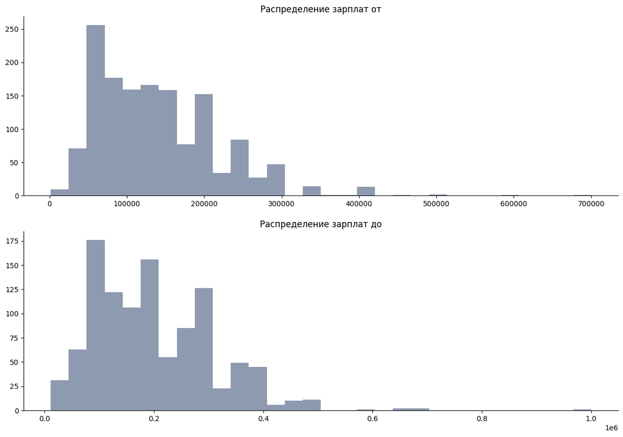

```python
# Изучим распределения
fig, axes = plt.subplots(nrows=2, ncols=1, figsize=(15, 10))
axes[0].hist(df_copy['salary_from'], bins=30, color='#8e9aaf')
axes[0].set_title('Распределение зарплат от')
axes[1].hist(df_copy['salary_to'], bins=30, color='#8e9aaf')
axes[1].set_title('Распределение зарплат до')
sns.despine()
# Показываем графики
plt.show()
```

Нам удалось уменьшить количество аномальных значений, не смотря на это в данных осталось некоторое количество вакансий с зарплатами которые можно отнести к выбросам. Оставим их как есть потому что данные реальные и их следует учитывать.

```python
df_copy.info()
```

```
<class 'pandas.core.frame.DataFrame'>
Int64Index: 8143 entries, 0 to 8142
Data columns (total 21 columns):
 #   Column                   Non-Null Count  Dtype
---  ------                   --------------  -----
 0   id                       8143 non-null   int64
 1   name                     8143 non-null   object
 2   published_at             8143 non-null   object
 3   alternate_url            8143 non-null   object
 4   employer                 8143 non-null   object
 5   department               1837 non-null   object
 6   area                     8143 non-null   object
 7   experience               8143 non-null   object
 8   schedule                 8143 non-null   object
 9   employment               8143 non-null   object
 10  salary_from              1451 non-null   float64
 11  salary_to                1070 non-null   float64
 12  description              8143 non-null   object
 13  description_lemmatized   8143 non-null   object
 14  profession               8143 non-null   object
 15  key_skills_standardized  8143 non-null   object
 16  hard_skills              7797 non-null   object
 17  soft_skills              4221 non-null   object
 18  salary_bin               8143 non-null   object
 19  education_level          8143 non-null   object
 20  employer_category        8143 non-null   object
dtypes: float64(2), int64(1), object(18)
memory usage: 1.4+ MB
```

### Выводы по этапу предобработки

Таким образом, проведённые изменения и обработка данных позволили улучшить их качество и снизить объём памяти, обеспечив возможность более точного и эффективного анализа.

Следующим этапом выполним исследовательский анализ данных в ходе которого:

1. Изучим как распределены вакансии по местоположению.
2. Изучим как распределены вакансии по требуемому образованию.
3. Изучим как типу занятости и графику работы.
4. Изучим как распределены вакансии по зарплатной категории.
5. Подсчитаем медианную зарплату для специалистов всех уровней.
6. Определим долю грейдов Junior, Junior+, Middle, Senior среди вакансий «аналитика данных» и «системного аналитика». Столбчатые диаграммы,
7. Определим типичное место работы для «аналитика данных» и «системного аналитика» по следующим параметрам: ТОП-работодатель, зарплата, тип занятости, график работы.(По каждому грейду) Как определить ТОП- работодателя? По количеству вакансий? По предлагаемым условиям? Типичная зарплата - медианная зарплата специалиста соответствующего грейда, определение наиболее популярных типов занятости и графиков работы.
8. Определим, какие навыки спрашивают чаще - твердые или мягкие. К какому грейду и к какой специальности требований больше. Подсчет количества навыков которые требует работодатель по типу и грейду
9. Определим наиболее желаемых кандидатов на вакансии «аналитик данных» и «системный аналитик» по следующим параметрам: самые важные hard-skils, самые важные soft-skils (по каждому грейду). Составим портрет кандидата с учётом перечня наиболее часто требуемых навыков, опыта работы стажа и прочих факторов.

## Исследовательский анализ данных.

```python
# Зададим явно цвета
da_color = '#8e9aaf'
sa_color = '#fe5f55'
# Создадим кастомную палитру
custom_palette = [da_color, sa_color, '#b5e2fa', '#f5f3f4', '#fb2e01']
```

```python
# Отфильтруем наши данные и отбросим вакансии с неизвестным опытом.
df_filtered = df_copy.query('experience != "Неизвестно"')
```

### Как распределены вакансии по профессиям?

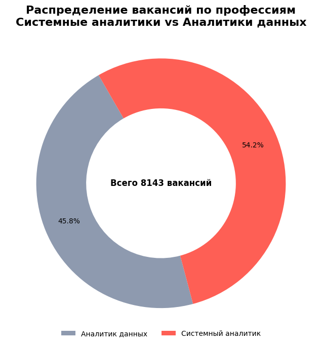

```python
# Зададим функцию для рисования пончиковой диаграммы
def plot_donut(data, center_text, ax, colors, labels):
    wedges, texts, autotexts = ax.pie(
        data,
        labels=None,
        autopct='%1.1f%%',
        startangle=120,
        pctdistance=0.8,
        colors=colors[:len(data)],
        wedgeprops=dict(width=0.4)
    )
    # Добавляем центральный текст
    ax.text(0, 0, center_text, ha='center', va='center', fontsize=12, fontweight='bold')

    # Добавляем легенду и помещаем её вниз
    ax.legend(
        labels=labels,
        loc='upper center',
        fontsize=10,
        title='',
        frameon=False,
        title_fontsize=12,
        bbox_to_anchor=(0.5, 0.05),
        ncol=4
    )


# Подсчитываем количество вакансий по профессии
profession_counts = df_filtered['profession'].value_counts().sort_values(ascending=True)

# Рисуем диаграмму
fig, ax = plt.subplots(figsize=(8, 8))

# Применяем функцию
plot_donut(
    profession_counts,
    f"Всего {len(df_copy)} вакансий",
    ax,
    custom_palette,
    profession_counts.index
)

# Добавляем заголовок
plt.title('Распределение вакансий по профессиям\nСистемные аналитики vs Аналитики данных',
             fontsize=16, fontweight='bold', pad=-30)

# Настройка и отображение
plt.show()
```

### Как распределены вакансии по опыту?

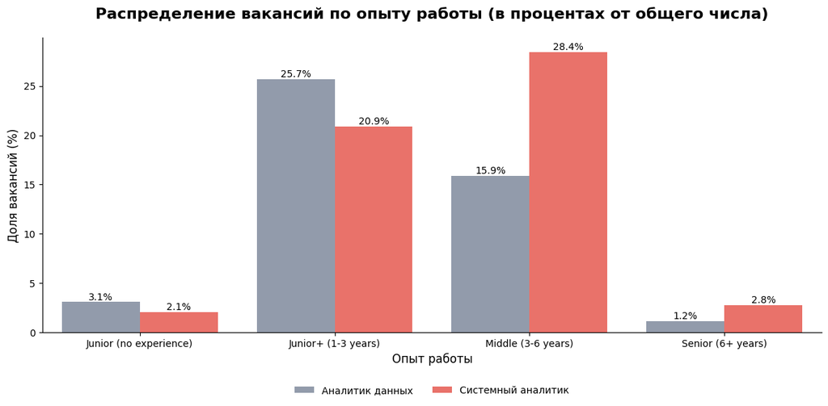

```python
# Подготовка данных для графика с процентами
experience_distribution = (
    df_filtered.groupby(['profession','experience'])['id']
    .count()
    .reset_index(name='count')
)

# Общий итог по всем профессиям и уровням опыта
total_count = df_filtered['id'].count()

# Вычисляем доли для отображения в процентах от общего количества вакансий
experience_distribution['percentage'] = (
    experience_distribution['count'] / total_count * 100
)

# Построение графика
plt.figure(figsize=(12, 6))
ax = sns.barplot(
    data=experience_distribution,
    x='experience',
    y='percentage',
    hue='profession',
    palette=custom_palette
)

# Настройка текста над столбцами
for p in ax.patches:
    height = p.get_height()
    if height > 0:
        ax.text(
            p.get_x() + p.get_width() / 2,
            height,
            f'{height:.1f}%',
            ha='center',
            va='bottom',
            fontsize=10
        )

# Настройка осей и заголовков
plt.title('Распределение вакансий по опыту работы (в процентах от общего числа)', fontsize=16, fontweight='bold', pad=20)
plt.xlabel('Опыт работы', fontsize=12)
plt.ylabel('Доля вакансий (%)', fontsize=12)
plt.xticks(fontsize=10)
plt.yticks(fontsize=10)
sns.despine()

# Настройка легенды
plt.legend(
    title='',
    fontsize=10,
    title_fontsize=12,
    loc='upper center',
    bbox_to_anchor=(0.5, -0.15),
    ncol=2,
    frameon=False
)

# Отображение графика
plt.tight_layout()
plt.show()
```